[figure not shown]

# InSituASProfile

The goal of InSituASProfile is to provide an easy way to calculate the insitu sprint acceleration-speed profile based on gps data using the method described by Morin et al. 2021 published in Journal of Biomechanics, DOI: 10.1016/j.jbiomech.2021.110524

## Installation

You can install the development version of InSituASProfile from [GitHub](https://github.com/) with:

```r
# install.packages("devtools")
devtools::install_github("LasseIshoi/ASProfile")
```

## Example

This is a basic example of how to use the InSituASProfile Package:

Import data (csv files) from folder and combine in single data frame for analysis.

```r
library(InSituASProfile)

library(here)
InSituASProfile::import_data(here("./data/"), "speed", "acc")
```

## Prepare data

This step cleans the data frame by 1) omitting all acceleration values below 0, 2) identify the two highest acceleration values for every consecutive 0.2 m/s cut starting from 3 m/s, and 3) create an initial regression line and associated preliminary plot (if not FALSE)

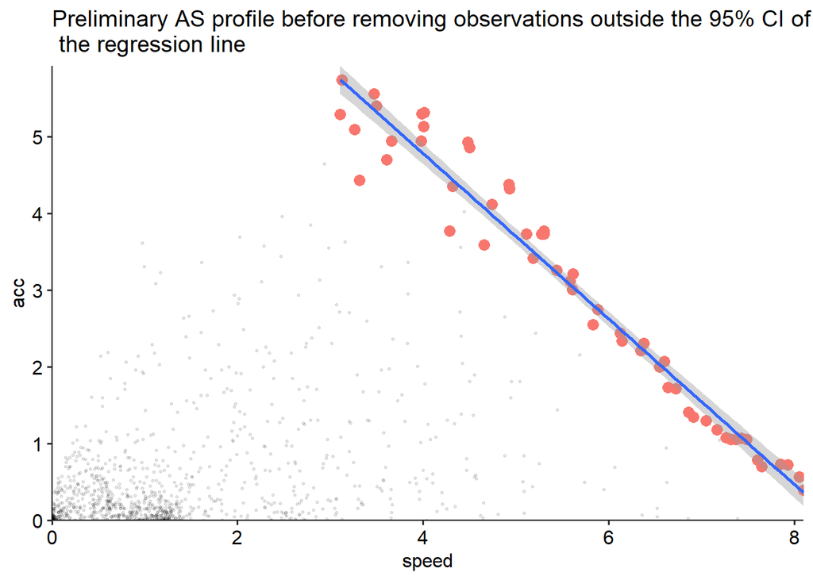

```r
InSituASProfile::prepare_data(data_import, print_plot = TRUE)
```

## Calculate the AS Profile

Calculate the A-S Profile. This step uses the data exported from prepare_data, and to calculate the A-S Profile. It plots the A-S Profile as default (TRUE), while a plot showing the regression line is not printed by default (FALSE).

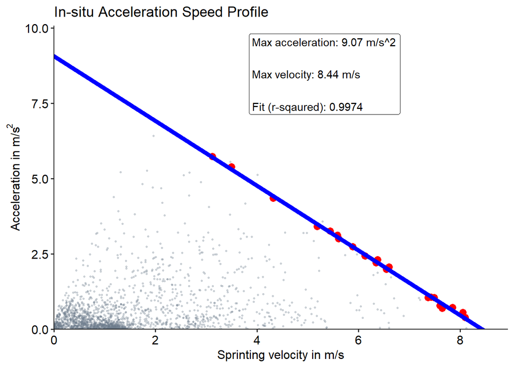

```r
InSituASProfile::get_AS_Profile(print_plot_regression_line = FALSE, print_AS_plot = TRUE)
```